# Text Mining Exploration: Practice Problem

Load the packages needed for this practice set of problems:

```r
library(tidyverse)   # for visualization and data transformation
library(tidytext)    # for tidy text mining
library(slam)
library(topicmodels) # for topic modeling with LDA
```

Read the dataset for this exercise:

```r
text_rei <- read_csv("https://github.com/reisanar/datasets/raw/master/fl_20_text.csv")
```

Take a look a random sample from the dataset:

```r
sample(t(text_rei), size = 5)
```

```
[1] "document_03"
[2] "document_02"
[3] "I've heard about the reproducibility crisis in the past. I think a simple solution to combat the crisis is to make all information open and available on GitHub with strong documentation and available data to support the study. This would allow for others to re-run the study, and perhaps even mo…
[4] "document_03"
[5] "document_01"
```

# Tokenization and `tf-idf`

**Perform tokenization using TF-IDF**

Recall that: in [TF-IDF](https://en.wikipedia.org/wiki/Tf%E2%80%93idf) (term frequency – inverse document frequency)

- TF = frequency of term
- IDF = logarithm of inverse of the frequency with which documents have that term

More formally, for a given document $d$ and term $t$, the **Term Frequency** is the number of times term $t$ appears in document $d$ :

$$TF(d, t) = \text{# times }t \text{ appears in document }d$$

To account for terms that appear frequently in the domain of interest, we compute the **Inverse Document Frequency** of term $t$, calculated over the entire corpus and defined as

$$IDF(t) = \ln\left( \frac{\text{total number of documents}}{\text{# documents containing term } t} \right)$$

- TF-IDF is high where a rare term is present or frequent in a document
- TF-IDF is near zero where a term is absent from a document, or abundant across all documents

We can use the `tidytext::bind_tf_idf()` function to easily compute TFIDF for every term:

[output not shown]

[output cut: 208 more lines]

Explore:

| due_date | word | n | tf | idf | tf_idf |
| --- | --- | --- | --- | --- | --- |
| document_01 | rule | 53 | 0.0113782739 | 1.0986123 | 0.0125003116 |
| document_01 | she | 34 | 0.0072992701 | 1.0986123 | 0.0080190678 |
| document_01 | association | 71 | 0.0152425934 | 0.4054651 | 0.0061803398 |
| document_01 | mining | 61 | 0.0130957492 | 0.4054651 | 0.0053098694 |
| document_02 | he | 66 | 0.0118491921 | 0.4054651 | 0.0048044340 |
| document_01 | algorithm | 17 | 0.0036496350 | 1.0986123 | 0.0040095339 |
| document_02 | music | 47 | 0.0084380610 | 0.4054651 | 0.0034213393 |
| document_03 | source | 20 | 0.0030252609 | 1.0986123 | 0.0033235888 |
| document_01 | apriori | 14 | 0.0030055818 | 1.0986123 | 0.0033019691 |
| document_03 | cran | 17 | 0.0025714718 | 1.0986123 | 0.0028250505 |

[output cut: 990 more lines]

Create a visualization showing the top TF-IDF scores in the text data for this exercise:

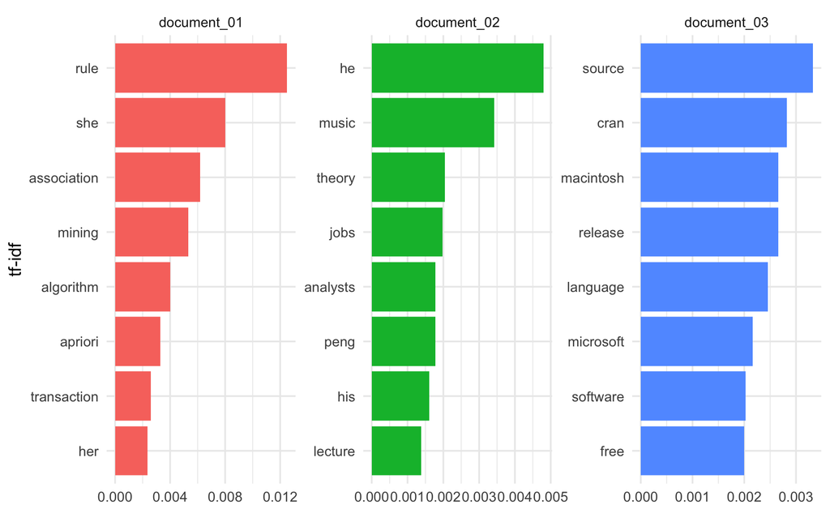

Save the visualization you create above (you can do this with `ggsave()` and select the format you want, for example `.pdf` or `.png` formats)

```r
ggsave("text_tf-idf.png", text_plot, width = 10, height = 4)
```

# Topic Modeling

We will use Latent Dirichlet Allocation (LDA) for topic modeling, using the `topicmodels` package.

Right now our data frame is in a tidy form, with **one-term-per-document-per-row**, but the `topicmodels` package requires a `DocumentTermMatrix`. We can *cast* a one-token-per-row table into a `DocumentTermMatrix` with `tidytext`’s function `cast_dtm()`. Additionally we remove any stop words.